# Biostat 200C Homework 3

Due May 9 @ 11:59PM

Published

May 9, 2025

```r
library(tidyverse)
library(MASS)
library(dplyr)
library(faraway)
library(ggplot2)
library(knitr)
library(patchwork)
```

```r
data(dvisits)
```

**NOTE: Questions other than Question 3 (using the ELMR book) are attached to the end of the PDF document.

## 1 Q3. ELMR Chapter 5 Exercise 5 (page 100) (70pts)

The dvisits data comes from the Australian Health Survey of 1977–1978 and consist of 5190 single adults where young and old have been oversampled.

1. Make plots which show the relationship between the response variable, doctorco, and the potential predictors, age and illness.

**Solution**

1. Plot for Doctor Visits versus Age: The scatter plot with a smoothed LOESS curve illustrates the relationship between age and the number of doctor visits (doctorco). The overall trend indicates a slight positive association, suggesting that as individuals age, the number of doctor visits tends to increase (by slightly). The plot reveals that most data points are concentrated at lower visit counts (primarily 0 and 1), indicating that a significant portion of the sample reports few or no doctor visits, regardless of age. The red smoothed line shows a gradual upward trend, particularly in the higher age range, suggesting that older individuals may utilize healthcare services slightly more frequently. This pattern is consistent with expectations, as age is typically associated with greater health concerns and increased medical needs.

```r
dvisits <- dvisits %>%
mutate(age_group = cut(age*100, breaks = c(15, 25, 35, 45, 55, 65, 75),
labels = c("15-24", "25-34", "35-44", "45-54", "55-64",
"65+")))
```

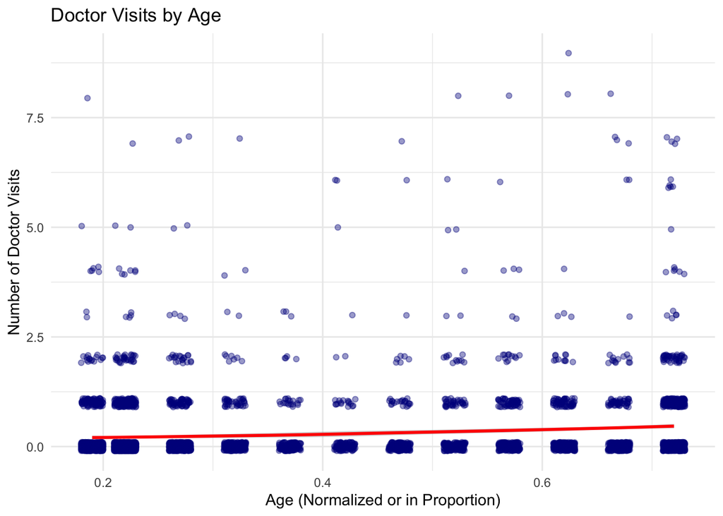

```r
ggplot(dvisits, aes(x = age, y = doctorco)) +
  geom_jitter(alpha = 0.4, color = "darkblue", width = 0.01, height = 0.1) +
  geom_smooth(method = "loess", color = "red", se = TRUE) +
  labs(
    title = "Doctor Visits by Age",
    x = "Age (Normalized or in Proportion)",
    y = "Number of Doctor Visits"
  ) +
  theme_minimal()
```

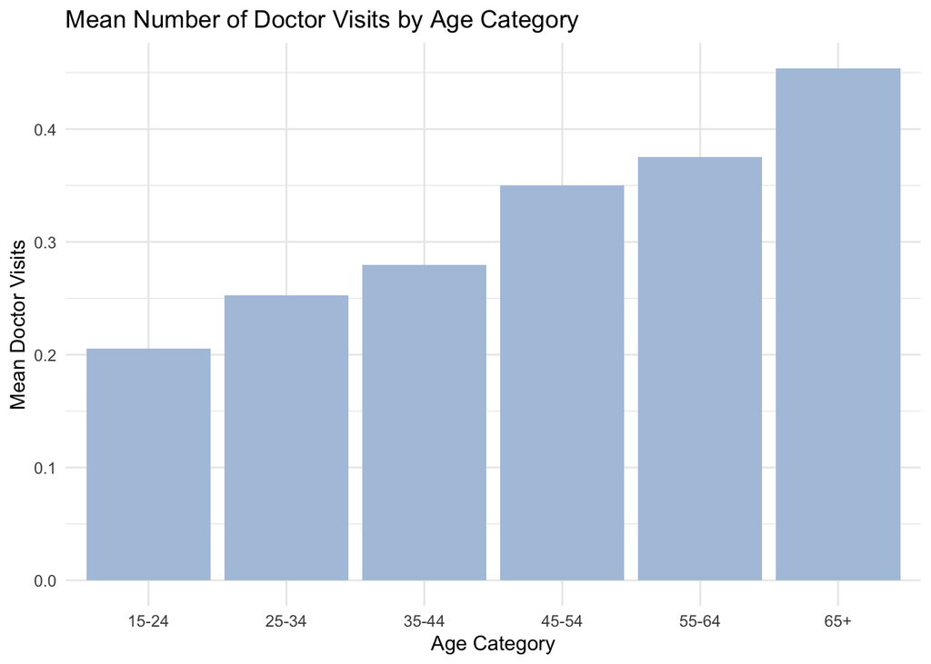

```r
age_summary <- dvisits %>%
  group_by(age_group) %>%
  summarise(mean_visits = mean(doctorco, na.rm = TRUE))

ggplot(age_summary, aes(x = age_group, y = mean_visits)) +
  geom_bar(stat = "identity", fill = "lightsteelblue") +
  labs(
    title = "Mean Number of Doctor Visits by Age Category",
    x = "Age Category",
    y = "Mean Doctor Visits"
  ) +
  theme_minimal()
```

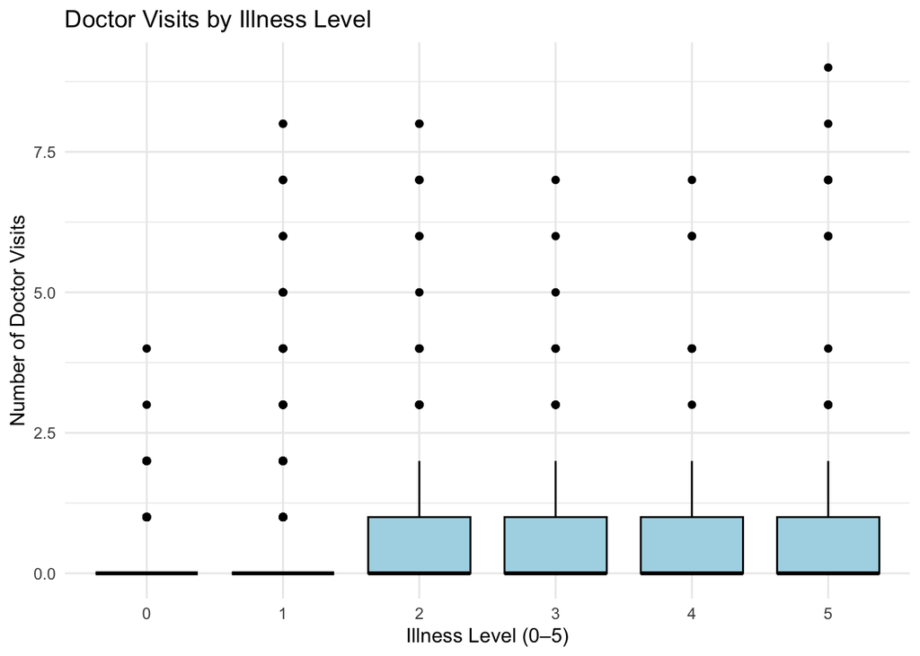

```r
ggplot(dvisits, aes(x = factor(illness), y = doctorco)) +
  geom_boxplot(fill = "lightblue", color = "black") +
  labs(
    title = "Doctor Visits by Illness Level",
    x = "Illness Level (0–5)",
    y = "Number of Doctor Visits"
  ) +
  theme_minimal()
```

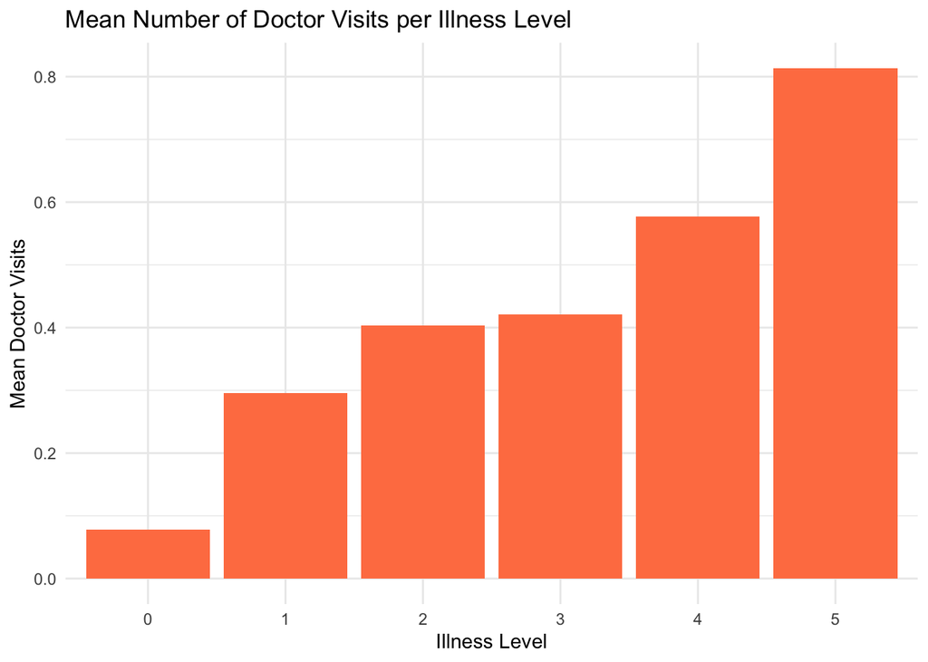

```r
illness_visits_summary <- dvisits %>%
  group_by(illness) %>%
  summarise(avg_visits = mean(doctorco, na.rm = TRUE))

ggplot(illness_visits_summary, aes(x = factor(illness), y = avg_visits)) +
  geom_bar(stat = "identity", fill = "coral") +
  labs(
    title = "Mean Number of Doctor Visits per Illness Level",
    x = "Illness Level",
    y = "Mean Doctor Visits"
  ) +
  theme_minimal()
```

2. Combine the predictors chcond1 and chcond2 into a single three-level factor. Make an appropriate plot showing the relationship between this factor and the response. Comment.

**Solution**

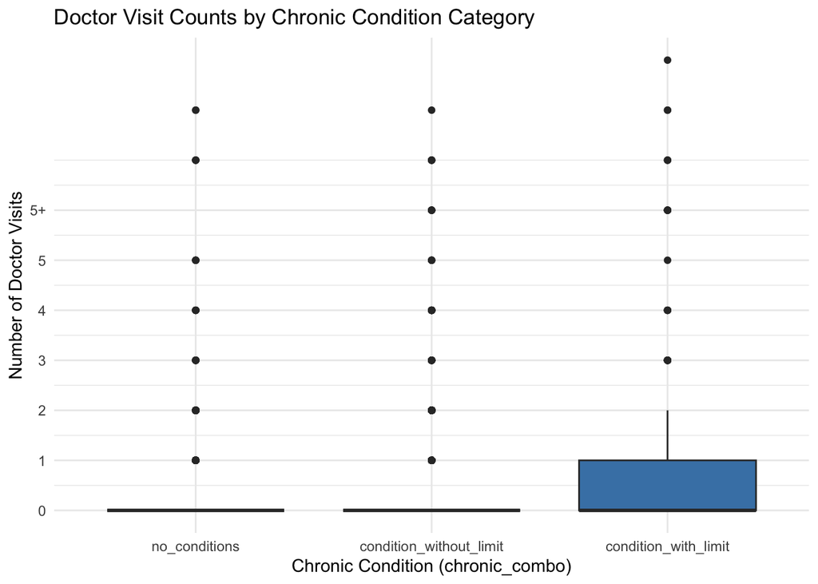

```r
dvisits <- dvisits %>%
  mutate(chronic_combo = case_when(
    chcond1 == 0 & chcond2 == 0 ~ "no_conditions",
    chcond1 == 1 & chcond2 == 0 ~ "condition_without_limit",
    chcond1 == 0 & chcond2 == 1 ~ "condition_with_limit",
    TRUE ~ NA_character_
  ))

dvisits$chronic_combo <- factor(dvisits$chronic_combo,
                                levels = c("no_conditions", "condition_without_limit", "condition_with_limit"))

dvisits <- dvisits %>%
  mutate(doctor_visits_capped = ifelse(doctorco >= 5, 5, doctorco),
         doctor_visits_capped = factor(doctor_visits_capped,
                                       levels = 0:5,
                                       labels = c("0", "1", "2", "3", "4", "5+")))

ggplot(dvisits, aes(x = chronic_combo, y = doctorco)) +
  geom_boxplot(fill = "steelblue") +
  scale_y_continuous(breaks = 0:6, labels = c("0", "1", "2", "3", "4", "5", "5+")) +
  labs(
    title = "Doctor Visit Counts by Chronic Condition Category",
    x = "Chronic Condition (chronic_combo)",
    y = "Number of Doctor Visits"
  ) +
  theme_minimal()
```

3. Build a Poisson regression model with doctorco as the response and sex, age, agesq, income, levyplus, freepoor, freerepa, illness, actdays, hscore and the three-level condition factor as possible predictor variables. Considering the deviance of this model, does this model fit the data?

**Solution**

The Poisson regression model below fitted the doctorco (number of doctor visits) as the response variable and a set of predictors including sex, age, agesq, income, levyplus, freepoor, freerepa, illness, actdays, hscore and the three-level condition factor (chronic_combo) as possible predictor variables. The model summary is showcased below. We assess the model fit using the residual deviance, which represents the goodness of fit test statistic that assess how well the model predicts the observed outcomes in comparison to the performance of the saturated model. The residual deviance is calculated as: 2* log likelihood of the saturated model - 2*log likelihood of the fitted model. The residual deviance of this fitted model comes out to be 4379.5 on 5177 degrees of freedom. The residual deviance (4379.5) is much lower than the null deviance (5634.8). The deviance to degrees of freedom ratio (4379.5/5177 = 0.846) is close to 1 which indicates that the Poisson model’s assumption of mean = variance is plausible. The 0.846 ratio is slightly below 1, which suggests possible underdispersion (less variability than expected under the Poisson distribution). However, we can conclude that the model fits reasonably well, as predictors significantly explain variability (large drop in deviance from the null model). In addition, there no indication of severe overdispersion, but slight underdispersion which suggests that the Poisson model may be acceptable.

```r
model_pois <- glm(doctorco ~ sex + age + I(age^2) + income + levyplus +
                  freepoor + freerepa + illness + actdays + hscore +
                  chronic_combo,
                  data = dvisits, family = poisson)
```

```r
summary(model_pois)
```

```
Call:
glm(formula = doctorco ~ sex + age + I(age^2) + income + levyplus +
    freepoor + freerepa + illness + actdays + hscore + chronic_combo,
    family = poisson, data = dvisits)

Coefficients:
                                      Estimate Std. Error z value Pr(>|z|)
(Intercept)                          -2.223848   0.189816 -11.716   <2e-16 ***
sex                                   0.156882   0.056137   2.795   0.0052 **
age                                   1.056299   1.000780   1.055   0.2912
I(age^2)                             -0.848704   1.077784  -0.787   0.4310
income                               -0.205321   0.088379  -2.323   0.0202 *
levyplus                              0.123185   0.071640   1.720   0.0855 .
freepoor                             -0.440061   0.179811  -2.447   0.0144 *
freerepa                              0.079798   0.092060   0.867   0.3860
illness                               0.186948   0.018281  10.227   <2e-16 ***
actdays                               0.126846   0.005034  25.198   <2e-16 ***
hscore                                0.030081   0.010099   2.979   0.0029 **
chronic_combocondition_without_limit  0.114085   0.066640   1.712   0.0869 .
chronic_combocondition_with_limit     0.141158   0.083145   1.698   0.0896 .
---
Signif. codes:  0 '***' 0.001 '**' 0.01 '*' 0.05 '.' 0.1 ' ' 1

(Dispersion parameter for poisson family taken to be 1)

    Null deviance: 5634.8  on 5189  degrees of freedom
Residual deviance: 4379.5  on 5177  degrees of freedom
AIC: 6737.1

Number of Fisher Scoring iterations: 6
```

4. Plot the residuals and the fitted values — why are there lines of observations on the plot? Make a QQ plot of the residuals and comment.

**Solution**

Residuals versus Fitted Values Plot:

Additionally, there is a noticeable clustering of negative residuals, particularly associated with an excess of zero doctor visits. This leads to a dense horizontal band near the lower part of the plot, reflecting the high frequency of individuals with no doctor visits in the dataset.

Furthermore, the plot exhibits a slight funnel shape: the spread of residuals is wider for lower fitted values and narrows as the fitted values increase. This pattern suggests non-constant variance (heteroscedasticity), which violates a key assumption of the Poisson model—that the mean equals the variance. This visual evidence indicates potential issues with model fit and suggests that an alternative modeling approach, such as a quasi-Poisson or negative binomial model, may be more appropriate.

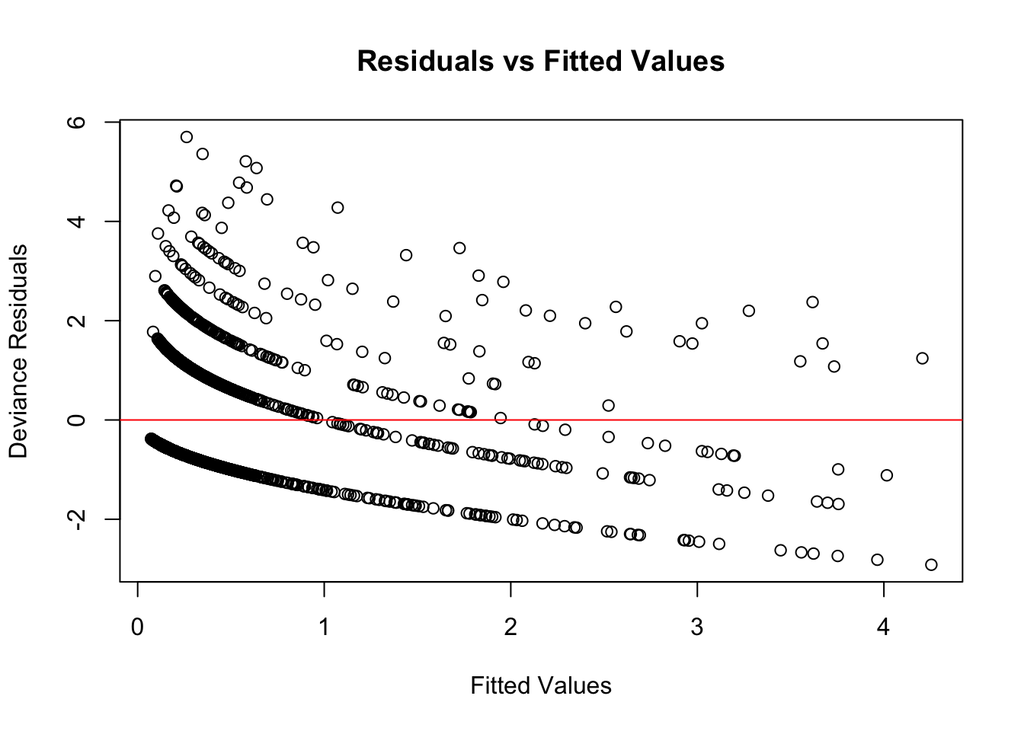

```r
fitted_vals <- fitted(model_pois)
residuals_dev <- residuals(model_pois, type = "deviance")

plot(fitted_vals, residuals_dev,
     xlab = "Fitted Values", ylab = "Deviance Residuals",
     main = "Residuals vs Fitted Values")
abline(h = 0, col = "red")
```

QQ Plot of Deviance Residuals:

The QQ plot of deviance residuals compares the distribution of the residuals from the Poisson regression model to a theoretical normal distribution. There is a clear and systematic deviation from the diagonal reference line, especially at the tails, indicating that the residuals do not follow a normal distribution. In the right tail, many residuals rise sharply above the expected quantiles, while in the left tail, several fall well below the line. These deviations suggest asymmetry and heavy tails, both of which are signs of model misfit.

The middle portion of the QQ plot displays a flat, stair-step pattern rather than a smooth progression along the line. This is a result of the discrete nature of the Poisson model, where repeated response values (such as 0s and 1s) lead to residuals that stack at similar quantiles.

The presence of extreme residuals at both ends of the plot further points to outliers and skewness in the data—strong indicators of model misspecification or inadequate fit. Overall, the QQ plot suggests that the Poisson model does not fully capture the variability in the data, potentially violating its core assumption that the mean equals the variance.

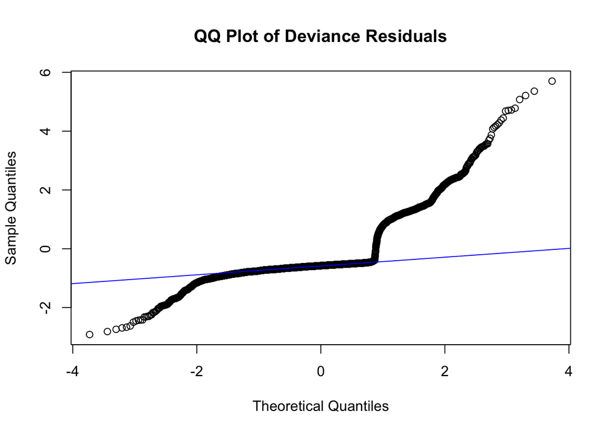

```r
qqnorm(residuals_dev, main = "QQ Plot of Deviance Residuals")
qqline(residuals_dev, col = "blue")
```

5. Use a stepwise AIC-based model selection method. What sort of person would be predicted to visit the doctor the most under your selected model?

**Solution** The stepwise AIC-based model selection method was applied to the initial Poisson regression model. The resulting model includes the following predictors: sex, age, income, illness, levyplus, freepoor, actays, hscore, and chronic_combo. The final model has a residual deviance of 4381.0 on 5179 degrees of freedom, with a AIC score of 6734.53.

```r
model_step <- stepAIC(model_pois, direction = "both")
```

```
Start:  AIC=6737.08
doctorco ~ sex + age + I(age^2) + income + levyplus + freepoor +
    freerepa + illness + actdays + hscore + chronic_combo

                Df Deviance    AIC
- I(age^2)       1   4380.1 6735.7
- freerepa       1   4380.3 6735.8
- age            1   4380.6 6736.2
- chronic_combo  2   4383.2 6736.7
<none>               4379.5 6737.1
- levyplus       1   4382.5 6738.1
- income         1   4385.0 6740.5
- freepoor       1   4386.2 6741.8
- sex            1   4387.4 6743.0
- hscore         1   4388.1 6743.7
- illness        1   4481.8 6837.4
- actdays        1   4917.1 7272.7

Step:  AIC=6735.7
doctorco ~ sex + age + income + levyplus + freepoor + freerepa +
    illness + actdays + hscore + chronic_combo

                Df Deviance    AIC
- freerepa       1   4381.0 6734.5
<none>               4380.1 6735.7
- chronic_combo  2   4384.2 6735.8
- age            1   4383.0 6736.5
- levyplus       1   4383.3 6736.9
+ I(age^2)       1   4379.5 6737.1
- income         1   4385.0 6738.6
- freepoor       1   4386.8 6740.4
- sex            1   4388.0 6741.5
- hscore         1   4389.1 6742.7
- illness        1   4481.9 6835.4
- actdays        1   4917.1 7270.7

Step:  AIC=6734.53
doctorco ~ sex + age + income + levyplus + freepoor + illness +
    actdays + hscore + chronic_combo

                Df Deviance    AIC
<none>               4381.0 6734.5
- levyplus       1   4383.4 6735.0
- chronic_combo  2   4385.5 6735.0
+ freerepa       1   4380.1 6735.7
+ I(age^2)       1   4380.3 6735.8
- income         1   4386.7 6738.2
- age            1   4387.1 6738.7
- freepoor       1   4389.1 6740.6
- sex            1   4389.5 6741.0
- hscore         1   4390.2 6741.8
- illness        1   4482.7 6834.2
- actdays        1   4917.6 7269.2
```

```r
summary(model_step)
```

```
Call:
glm(formula = doctorco ~ sex + age + income + levyplus + freepoor +
    illness + actdays + hscore + chronic_combo, family = poisson,
    data = dvisits)

Coefficients:
                                      Estimate Std. Error z value Pr(>|z|)
(Intercept)                          -2.089063   0.100811 -20.723  < 2e-16 ***
sex                                   0.162000   0.055824   2.902  0.00371 **
age                                   0.355131   0.143196   2.480  0.01314 *
income                               -0.199806   0.084328  -2.369  0.01782 *
levyplus                              0.083689   0.053544   1.563  0.11805
freepoor                             -0.469596   0.176360  -2.663  0.00775 **
illness                               0.186101   0.018260  10.191  < 2e-16 ***
actdays                               0.126611   0.005029  25.177  < 2e-16 ***
hscore                                0.031116   0.010065   3.092  0.00199 **
chronic_combocondition_without_limit  0.121100   0.066389   1.824  0.06814 .
chronic_combocondition_with_limit     0.158894   0.081762   1.943  0.05197 .
---
Signif. codes:  0 '***' 0.001 '**' 0.01 '*' 0.05 '.' 0.1 ' ' 1

(Dispersion parameter for poisson family taken to be 1)

    Null deviance: 5634.8  on 5189  degrees of freedom
Residual deviance: 4381.0  on 5179  degrees of freedom
AIC: 6734.5

Number of Fisher Scoring iterations: 6
```

6. For the last person in the dataset, compute the predicted probability distribution for their visits to the doctor, i.e., give the probability they visit 0, 1, 2, etc. times.

**Solution**

Based on the Poisson regression model, the predicted number of doctor visits for the last person in the dataset is centered around zero visits. The model estimates an 85.89% probability that this person will not visit the doctor at all, followed by a 13.06% chance of making exactly one visit. The probabilities for two or more visits drop off sharply, with only a 0.99% chance of two visits, and even lower probabilities after the number of visits hit 3 visits. This distribution indicates that the individual has a very low expected rate of doctor visits. The highly right-skewed distribution is typical in Poisson models for count data, especially when the mean count is close to zero.

```r
last_person <- dvisits[nrow(dvisits), ]
lambda <- predict(model_step, newdata = last_person, type = "response")

visit_range <- 0:10
probabilities <- dpois(visit_range, lambda)

prob_dist <- data.frame(
  `Number of Visits` = visit_range,
  `Probability` = probabilities
)

kable(prob_dist, digits = 5, caption = "Predicted Probability Distribution for Doctor Visits")
```

Predicted Probability Distribution for Doctor Visits

| Number.of.Visits | Probability |
| --- | --- |
| 0 | 0.85892 |
| 1 | 0.13063 |
| 2 | 0.00993 |
| 3 | 0.00050 |
| 4 | 0.00002 |
| 5 | 0.00000 |
| 6 | 0.00000 |
| 7 | 0.00000 |
| 8 | 0.00000 |
| 9 | 0.00000 |
| 10 | 0.00000 |

7. Tabulate the frequencies of the number of doctor visits. Compute the expected frequencies of doctor visits under your most recent model. Compare the observed with the expected frequencies and comment on whether it is worth fitting a zero-inflated count model.

**Solution** The code below tabulates the observed frequencies of doctor visits (doctorco) and predicts the expected number of visits for each individual in the dataset using the most recent Poisson regression model, obtained through stepwise AIC-based model selection. It then computes the expected frequency distribution across visit counts (from 0 to the maximum observed) by averaging the Poisson probabilities for each count across all individuals. The resulting comparison table shows that the observed and expected frequencies are closely aligned, particularly for 0 and 2 visits. The largest discrepancy occurs at 1 visit, where the model slightly overestimates (928.35 expected vs. 782 observed). Notably, the number of zero visits is very well predicted by the model (4141 observed vs. 4013.60 expected).

```r
observed_freq <- table(dvisits$doctorco)
predicted_lambda <- predict(model_step, type = "response")

visit_range <- 0:max(dvisits$doctorco)
expected_probs <- colMeans(sapply(visit_range, function(k) dpois(k, predicted_lambda)))
expected_freq <- expected_probs * nrow(dvisits)

comparison_df <- data.frame(
  `Number of Visits` = visit_range,
  `Observed Frequency` = as.numeric(observed_freq[as.character(visit_range)]),
  `Expected Frequency` = round(expected_freq, 2)
)

comparison_df$Observed.Frequency[is.na(comparison_df$Observed.Frequency)] <- 0
kable(comparison_df, digits = 2, caption = "Observed vs. Expected Frequencies of Doctor Visits (Poisson Model)")
```

Observed vs. Expected Frequencies of Doctor Visits (Poisson Model)

| Number.of.Visits | Observed.Frequency | Expected.Frequency |
| --- | --- | --- |
| 0 | 4141 | 4013.60 |
| 1 | 782 | 928.35 |
| 2 | 174 | 168.01 |
| 3 | 30 | 45.49 |
| 4 | 24 | 18.91 |
| 5 | 9 | 8.82 |
| 6 | 12 | 4.01 |
| 7 | 12 | 1.72 |
| 8 | 5 | 0.69 |
| 9 | 1 | 0.26 |

8. Fit a comparable (Gaussian) linear model and graphically compare the fits. Describe how they differ.

We observe that the Poisson model produces a wider and more dispersed range of fitted values, particularly for low observed counts. This better reflects the skew and variability often present in real-world count data. The Gaussian model, however, generates smoother, more compressed fitted values that tend to cluster tightly around the mean. It also underestimates higher visit counts and often assigns similar predicted values to very different observations.

The Poisson model more effectively captures the long tail of higher doctor visit counts, whereas the Gaussian model struggles—frequently predicting much lower fitted values for individuals with high observed visits due to its inability to accommodate skewed distributions. Therefore, we conclude that the Poisson model provides a better and more practical fit for this dataset, as it respects the count nature of the response variable and handles skew more appropriately.

```r
model_pois <- glm(doctorco ~ sex + age + I(age^2) + income + levyplus +
                 freepoor + freerepa + illness + actdays + hscore + chronic_combo,
                 family = poisson, data = dvisits)

dvisits$sqrt_visits <- sqrt(dvisits$doctorco + 0.5)
model_gauss <- lm(sqrt_visits ~ sex + age + I(age^2) + income + levyplus +
                freepoor + freerepa + illness + actdays + hscore + chronic_combo,
                data = dvisits)
```

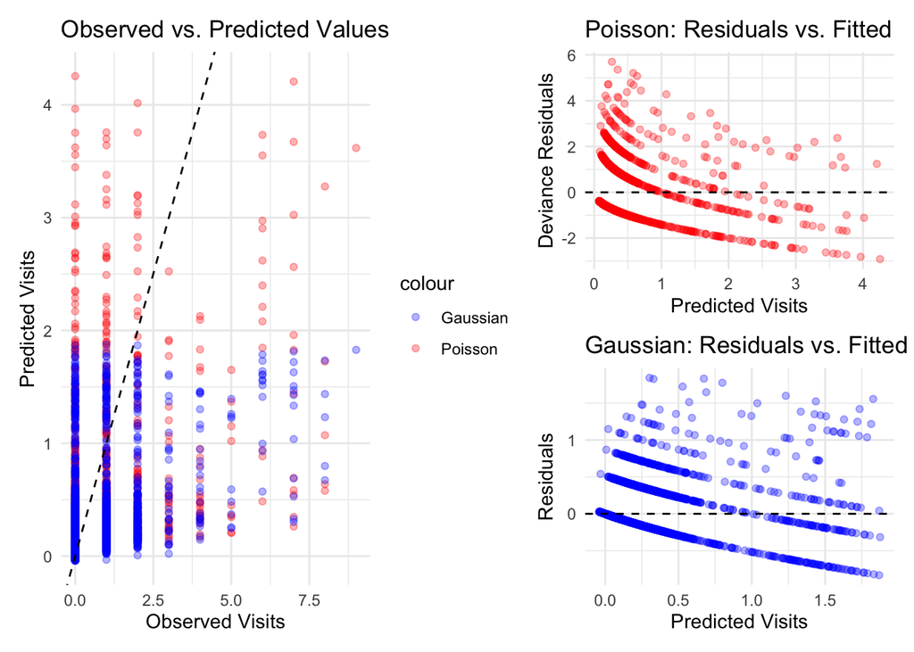

```r
dvisits <- dvisits %>%
  mutate(
    pois_pred = predict(model_pois, type = "response"),
    pois_resid = residuals(model_pois, type = "deviance"),

    gauss_pred = (predict(model_gauss))^2 - 0.5,
    gauss_resid = residuals(model_gauss)
  )

p1 <- ggplot(dvisits, aes(x = doctorco)) +
  geom_point(aes(y = pois_pred, color = "Poisson"), alpha = 0.3) +
  geom_point(aes(y = gauss_pred, color = "Gaussian"), alpha = 0.3) +
  geom_abline(slope = 1, intercept = 0, linetype = "dashed") +
  labs(title = "Observed vs. Predicted Values",
       x = "Observed Visits", y = "Predicted Visits") +
  scale_color_manual(values = c("Poisson" = "red", "Gaussian" = "blue")) +
  theme_minimal()

p2 <- ggplot(dvisits, aes(x = pois_pred, y = pois_resid)) +
  geom_point(alpha = 0.3, color = "red") +
  geom_hline(yintercept = 0, linetype = "dashed") +
  labs(title = "Poisson: Residuals vs. Fitted",
       x = "Predicted Visits", y = "Deviance Residuals") +
  theme_minimal()

p3 <- ggplot(dvisits, aes(x = gauss_pred, y = gauss_resid)) +
  geom_point(alpha = 0.3, color = "blue") +
  geom_hline(yintercept = 0, linetype = "dashed") +
  labs(title = "Gaussian: Residuals vs. Fitted",
       x = "Predicted Visits", y = "Residuals") +
  theme_minimal()

(p1 | (p2 / p3)) + plot_layout(widths = c(1, 1))
```